# R을 이용한 데이터 전처리 숙제 1

Author

waterfirst

[figure not shown]

아래는 데이터 전처리 예제입니다. 문제와 답만 있습니다. 한주 동안 풀어보시고 다음 강의 (7/13 토)에 각자 나누어서 어떻게 풀었는지 설명하는 시간을 갖도록 하겠습니다.

## 1 airquality

*airquality* 데이터 셋

5월부터 9월까지 Ozone(오존), Solar(uv), Wind(풍속), Temp(온도)에 관한 데이터세트이다.

```r
library(tidyverse)
head(airquality)
```

```
  Ozone Solar.R Wind Temp Month Day
1    41     190  7.4   67     5   1
2    36     118  8.0   72     5   2
3    12     149 12.6   74     5   3
4    18     313 11.5   62     5   4
5    NA      NA 14.3   56     5   5
6    28      NA 14.9   66     5   6
```

#### 1. 열별 결측치가 몇개가 있는지 표시하라.

```
  Ozone Solar.R    Wind    Temp   Month     Day
     37       7       0       0       0       0
```

#### 2. 월별 Ozone의 평균과 Wind의 표준편차를 구하시오.

```
# A tibble: 5 × 3
  Month Ozone_평균 Wind_표준편차
  <int>      <dbl>         <dbl>
1     5       23.6          3.53
2     6       29.4          3.77
3     7       59.1          3.04
4     8       60.0          3.23
5     9       31.4          3.46
```

#### 3. 온도는 화씨로 되어 있는데, 섭씨 온도 Temp_C 를 새로운 열로 만들어라. 이때 소수 둘째자리에서 반올림해서 첫째자리까지 보이고 섭씨온도가 가장 높은 날은 몇월 몇일, 몇도인지 표시하라.

**섭씨 = (화씨 − 32) × 5/9**

```
  Month Day Temp_C
1     8  28   36.1
```

```
  Month Day Temp_C
1     8  28   36.1
```

#### 4. Solar.R이 150 이상인 날 중에 8월~9월 총 몇일이나 되는가

```
   n
1 38
```

#### 5. Ozone이 결측치가 있는 날 중에 월별 Wind의 세기의 중간값을 구하시오.

```
# A tibble: 5 × 2
  Month Wind_중간값
  <int>       <dbl>
1     5        14.3
2     6         9.2
3     7        10.9
4     8        11.5
5     9        13.2
```

## 2 diamonds

*diamonds* 데이터 셋

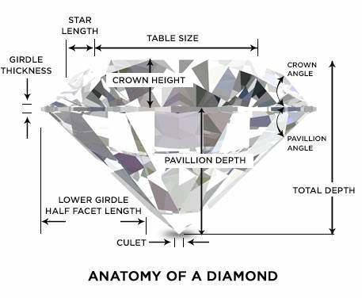

가격: 미국 달러 가격.

캐럿: 다이아몬드의 무게.

절단: 절단 품질(최악의 순서).

색: 다이아몬드의 색상(가장 나쁜 순서).

선명도: 다이아몬드의 선명도(최악의 순서).

x: 길이(mm).

y: 너비(mm).

z: 깊이(mm). 깊이:

총 깊이 백분율: 100 * z / 평균(x, y)

테이블: 가장 넓은 지점을 기준으로 다이아몬드 상단의 너비입니다.

```r
head(diamonds)
```

```
# A tibble: 6 × 10
  carat cut       color clarity depth table price     x     y     z
  <dbl> <ord>     <ord> <ord>   <dbl> <dbl> <int> <dbl> <dbl> <dbl>
1  0.23 Ideal     E     SI2      61.5    55   326  3.95  3.98  2.43
2  0.21 Premium   E     SI1      59.8    61   326  3.89  3.84  2.31
3  0.23 Good      E     VS1      56.9    65   327  4.05  4.07  2.31
4  0.29 Premium   I     VS2      62.4    58   334  4.2   4.23  2.63
5  0.31 Good      J     SI2      63.3    58   335  4.34  4.35  2.75
6  0.24 Very Good J     VVS2     62.8    57   336  3.94  3.96  2.48
```

#### 1. 열별 영어로 된 이름을 한글로 바꾸어라.

```
     캐럿 = carat,
     절단 = cut,
     색 = color,
     선명도 =clarity,
     깊이 = depth,
     상단너비 = table,
     가격 = price
```

```
# A tibble: 53,940 × 10
    캐럿 절단      색    선명도  깊이 상단너비  가격     x     y     z
   <dbl> <ord>     <ord> <ord>  <dbl>    <dbl> <int> <dbl> <dbl> <dbl>
 1  0.23 Ideal     E     SI2     61.5       55   326  3.95  3.98  2.43
 2  0.21 Premium   E     SI1     59.8       61   326  3.89  3.84  2.31
 3  0.23 Good      E     VS1     56.9       65   327  4.05  4.07  2.31
 4  0.29 Premium   I     VS2     62.4       58   334  4.2   4.23  2.63
 5  0.31 Good      J     SI2     63.3       58   335  4.34  4.35  2.75
 6  0.24 Very Good J     VVS2    62.8       57   336  3.94  3.96  2.48
 7  0.24 Very Good I     VVS1    62.3       57   336  3.95  3.98  2.47
 8  0.26 Very Good H     SI1     61.9       55   337  4.07  4.11  2.53
 9  0.22 Fair      E     VS2     65.1       61   337  3.87  3.78  2.49
10  0.23 Very Good H     VS1     59.4       61   338  4     4.05  2.39
# ℹ 53,930 more rows
```

#### 2. 가격이 평균보다 작은 다이아몬드를 clarity별로 몇개씩 있는지 구하라.

```
# A tibble: 8 × 2
  clarity     n
  <ord>   <int>
1 I1        480
2 SI2      4346
3 SI1      7612
4 VS2      7893
5 VS1      5510
6 VVS2     3856
7 VVS1     3098
8 IF       1488
```

#### 3. 깊이백분율 열을 아래 수식에 맞도록 새로 만든 후 head()를 쓴 후 , depth와 깊이백분율 열만 보이도록 하라. 이때 깊이백분율은 소수 첫째자리까지만 보이라.

**깊이백분율 = z / (x와 y의 평균) *100 **

```
# A tibble: 6 × 2
  깊이백분율 depth
       <dbl> <dbl>
1       61.3  61.5
2       59.8  59.8
3       56.9  56.9
4       62.4  62.4
5       63.3  63.3
6       62.8  62.8
```

#### 4. color별로 carat의 평균과 price의 중간값을 보여라. carat은 소수 둘째자리까지만 보이고, price의 내림차순으로 정렬하라.

```
# A tibble: 7 × 3
  color carat평균 price중간값
  <ord>     <dbl>       <dbl>
1 J          1.16       4234
2 I          1.03       3730
3 H          0.91       3460
4 F          0.74       2344.
5 G          0.77       2242
6 D          0.66       1838
7 E          0.66       1739
```

#### 5. cut이 Premium 인 것중에서 carat이 가장 큰 값을 가지는 diamond의 가격은 얼마인가?

```
# A tibble: 1 × 1
  price
  <int>
1 15223
```

## 3 Titanic

*Titanic* 데이터 셋

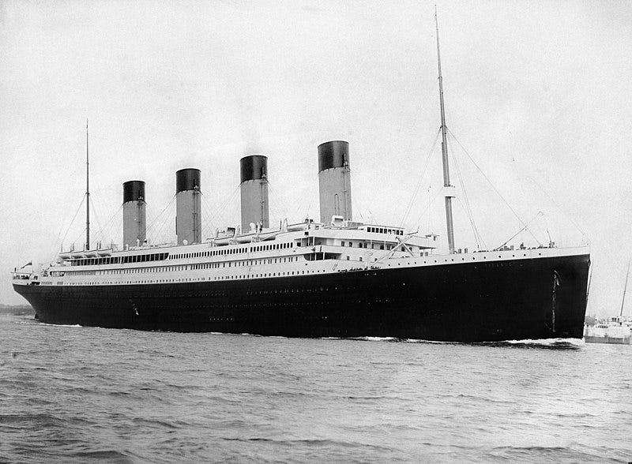

```
PassengerId: 각 승객에게 주어진 고유 ID 번호
Survived: 승객이 생존(1)했는지 사망(0)했는지 여부
Pclass: 승객 등급
Name: 이름
Sex: 승객의 성별
Age: 승객의 나이
SibSp: 형제자매/배우자의 수
Parch: 부모/자녀의 수
Ticket: 티켓 번호
Fare: 티켓에 대해 지불한 금액
Cabin: 객실 카테고리
Embarked: 승객이 탑승한 항구(C = Cherbourg, Q = Queenstown, S = Southampton)
```

r에서는 타이타닉 데이터를 좀더 간편하게 만든 내장데이터가 있다. data를 아래와 같이 불러와서 titanic 변수에 넣고 시작하자.

titanic <- as.data.frame(Titanic)

```r
titanic <- as.data.frame(Titanic)
head(titanic)
```

```
  Class    Sex   Age Survived Freq
1   1st   Male Child       No    0
2   2nd   Male Child       No    0
3   3rd   Male Child       No   35
4  Crew   Male Child       No    0
5   1st Female Child       No    0
6   2nd Female Child       No    0
```

#### 1. 탑승자 중 여자 아이의 총 수는 몇명인가?

```
   n
1 45
```

#### 2. Crew중 여자 어른의 수는 몇명인가?

```
   n
1 23
```

#### 3.Sex별, Age별 생존자가 몇명인지 보이시오.

```
# A tibble: 4 × 3
# Groups:   Sex [2]
  Sex    Age   생존자
  <fct>  <fct>  <dbl>
1 Male   Child     29
2 Male   Adult    338
3 Female Child     28
4 Female Adult    316
```

#### 4. 위 문제에서 Sex별, Age별 생존자의 비율은 얼마인가?

```
# A tibble: 4 × 5
# Groups:   Sex [2]
  Sex    Age   인원수 생존자 생존율
  <fct>  <fct>  <dbl>  <dbl>  <dbl>
1 Male   Child     64     29     45
2 Male   Adult   1667    338     20
3 Female Child     45     28     62
4 Female Adult    425    316     74
```

#### 5. Class별 생존율을 구하시오.

```
# A tibble: 4 × 4
  Class 인원수 생존자 생존율
  <fct>  <dbl>  <dbl>  <dbl>
1 1st      325    203     62
2 2nd      285    118     41
3 3rd      706    178     25
4 Crew     885    212     24
```